# Chapter 5: Linear Regression

```r
data <- read.csv(
  file = "returns.csv",
  sep = ";"
)
```

```r
data
```

| date | closes_alior | daily_returns_alior | daily_log_returns_alior | closes_ing | daily_returns_ing | daily_log_returns_ing |
| --- | --- | --- | --- | --- | --- | --- |
| 01/01/2023 | 30.16000 | NA | NA | 137.3500 | NA | NA |
| 02/01/2023 | 30.16000 | 0.000000 | 0.000000 | 137.3500 | 0.000000 | 0.000000 |
| 03/01/2023 | 33.37000 | 0.106432 | 0.101141 | 142.7100 | 0.039024 | 0.038282 |
| 04/01/2023 | 35.68000 | 0.069224 | 0.066933 | 148.0600 | 0.037489 | 0.036803 |
| 05/01/2023 | 36.27000 | 0.016536 | 0.016401 | 149.2300 | 0.007902 | 0.007871 |
| 06/01/2023 | 37.34000 | 0.029501 | 0.029074 | 152.7400 | 0.023521 | 0.023248 |
| 07/01/2023 | 37.80000 | 0.012319 | 0.012244 | 151.4100 | -0.008708 | -0.008746 |
| 08/01/2023 | 37.03000 | -0.020370 | -0.020581 | 150.5700 | -0.005548 | -0.005563 |
| 09/01/2023 | 36.26000 | -0.020794 | -0.021013 | 149.7300 | -0.005579 | -0.005594 |
| 10/01/2023 | 36.87000 | 0.016823 | 0.016683 | 152.2400 | 0.016764 | 0.016625 |

[output cut: 721 more lines]

## Returns and Log-Returns

In financial analysis, **returns** and **log-returns** play a key role in measuring the relative changes in asset prices over time.

### Simple Returns

A **simple return** calculates the relative change in price between consecutive periods:

$$R_t = \frac{P_t - P_{t-1}}{P_{t-1}}$$

where $P_t$ is the price at time $t$, and $P_{t-1}$ is the price in the previous period. Simple returns are intuitive, but they **do not add up linearly over time**, which can complicate multi-period analysis.

### Log-Returns

A **log-return** is defined as:

$$r_t = \ln\frac{P_t}{P_{t-1}} = \ln(P_t) - \ln(P_{t-1})$$

The advantage of log-returns is their **additivity over time** – the log-return over multiple periods is the sum of the individual period log-returns. They are also often more suitable for modeling financial data, especially when prices grow exponentially.

### Context in the Analyzed Data

Returns and log-returns were calculated in **Excel** and then imported into **R**, where **histograms** and a **scatter plot** comparing the log-returns of both companies were prepared. These visualizations allow for assessing the data distribution and the degree of interdependence between the companies.

```r
alior_log_returns <- data$daily_log_returns_alior[-1]
ing_log_returns <- data$daily_log_returns_ing[-1]
```

```r
# install.packages("ggplot2")
# install.packages("ggExtra")
library(ggplot2)
library(ggExtra)
```

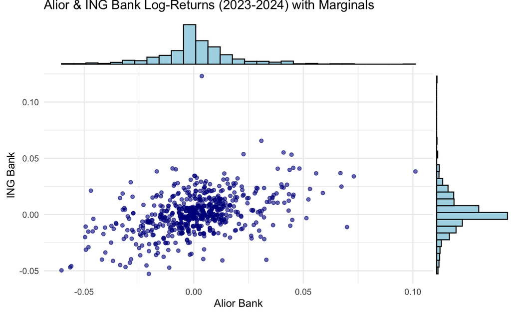

```r
alior_ing <- data.frame(
  alior_log_returns = alior_log_returns,
  ing_log_returns   = ing_log_returns
)

p <- ggplot(alior_ing, aes(x = alior_log_returns, y = ing_log_returns)) +
  geom_point(alpha = 0.6, color = "darkblue") +
  labs(
    title = "Alior & ING Bank Log-Returns (2023-2024) with Marginals",
    x = "Alior Bank",
    y = "ING Bank"
  ) +
  theme_minimal()

ggMarginal(
  p,
  type = "histogram",
  margins = "both",
  fill = "lightblue"
)
```

## Relationships Between Log-Returns

### Covariance

Covariance measures how two variables change together:

$$\text{Cov}(X, Y) = \frac{1}{n-1} \sum_{i=1}^{n} (X_i - \bar{X})(Y_i -
\bar{Y})$$

- $X_i$, $Y_i$ – observations of variables X and Y
- $\bar{X}$, $\bar{Y}$ – arithmetic means of the variables
- $n$ – number of observations

A positive covariance indicates that the log-returns of Alior and ING tend to move together – when one stock rises, the other usually rises as well. A negative covariance would suggest that an increase in one stock corresponds to a decrease in the other. A value close to zero indicates little or no linear relationship. In the banking sector, positive covariance is common, as stock prices often respond similarly to macroeconomic factors and monetary policy.

### Correlation

Correlation normalizes covariance, resulting in a value between $[-1,1]$, which makes it easier to assess the strength of the relationship.

#### Pearson Correlation (P)

$$r_P = \frac{\text{Cov}(X, Y)}{\sigma_X \sigma_Y}$$

Pearson correlation measures the linear relationship between Alior and ING log-returns. A value close to 1 means that changes in one stock’s log-returns are strongly associated with changes in the other in the same direction. A value close to -1 indicates a strong inverse relationship, and a value around 0 indicates little or no linear correlation. In our case, $r_P \approx 0.46$ shows a moderate positive linear relationship, meaning the stocks often move in the same direction but not perfectly in sync.

#### Spearman Correlation (S)

$$r_S = 1 - \frac{6 \sum d_i^2}{n(n^2-1)}$$

Spearman correlation is based on the ranks of observations and measures monotonic relationships, without assuming linearity. A positive value indicates that higher log-returns of one stock generally correspond to higher log-returns of the other, even if the relationship is not strictly linear. In practice, $r_S \approx 0.43$ confirms a moderate common trend in Alior and ING log-returns, consistent with expectations for the banking sector.

```r
cov(alior_log_returns, ing_log_returns)
```

```
[1] 0.0001352158
```

```r
cor(alior_log_returns, ing_log_returns, method = "pearson")
```

```
[1] 0.4638365
```

```r
cor(alior_log_returns, ing_log_returns, method = "spearman")
```

```
[1] 0.4286084
```

### Analysis of Log-Return Relationships Between Alior and ING

Analyzing covariance and correlation allows us to assess the extent to which the log-returns of two companies move together.

- **Positive covariance** indicates that Alior and ING log-returns tend to rise together. In other words, when one stock increases, the other generally also shows an upward movement.
- **Pearson correlation ($r \approx 0.46$)** shows a moderate positive linear relationship. This means that the stocks’ log-returns generally tend to move in the same direction, although some scatter exists and the relationship is not perfectly linear.
- **Spearman correlation ($r \approx 0.43$)** measures monotonic association and indicates that higher ING log-returns are usually associated with higher Alior log-returns, even if the relationship is not exactly linear.

In summary, both linear and monotonic analyses confirm a moderate positive dependence between Alior and ING log-returns, which is consistent with expectations for companies in the same banking sector.

## Linear Regression of Alior Log-Returns on ING

The purpose of linear regression is to create a model:

$$Y = \beta_0 + \beta_1 X + \varepsilon$$

- $\beta_0$ – intercept
- $\beta_1$ – slope (coefficient)
- $\varepsilon$ – random error

The model allows us to **describe the trend of the dependent variable $Y$ as a function of the independent variable $X$** and to predict future values.

### $R^2$ (Coefficient of Determination)

$$R^2 = 1 - \frac{\sum (Y_i - \hat{Y}_i)^2}{\sum (Y_i - \bar{Y})^2}$$

- $\hat{Y}_i$ – predicted values from the model
- $\bar{Y}$ – mean of observed values

**Interpretation:** - $R^2 \in [0,1]$  
- Explains the proportion of variance in the dependent variable that is accounted for by the independent variable in the model  
- Example: $R^2 = 0.8$ means 80% of the variance in $Y$ is explained by the linear model

```r
model <- lm(alior_log_returns ~ ing_log_returns)
summary(model)
```

```
Call:
lm(formula = alior_log_returns ~ ing_log_returns)

Residuals:
      Min        1Q    Median        3Q       Max
-0.061428 -0.006672 -0.000796  0.006681  0.080233

Coefficients:
                 Estimate Std. Error t value Pr(>|t|)
(Intercept)     0.0009562  0.0005943   1.609    0.108
ing_log_returns 0.5211673  0.0368928  14.127   <2e-16 ***
---
Signif. codes:  0 ‘***’ 0.001 ‘**’ 0.01 ‘*’ 0.05 ‘.’ 0.1 ‘ ’ 1

Residual standard error: 0.01604 on 728 degrees of freedom
Multiple R-squared:  0.2151,    Adjusted R-squared:  0.2141
F-statistic: 199.6 on 1 and 728 DF,  p-value: < 2.2e-16
```

```r
library(ggplot2)
library(ggExtra)
```

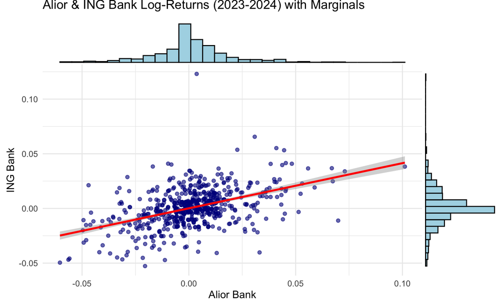

```r
p <- ggplot(alior_ing, aes(x = alior_log_returns, y = ing_log_returns)) +
  geom_point(alpha = 0.6, color = "darkblue") +
  geom_smooth(method = "lm", color = "red", se = TRUE) +
  labs(
    title = "Alior & ING Bank Log-Returns (2023-2024) with Marginals",
    x = "Alior Bank",
    y = "ING Bank"
  ) +
  theme_minimal()

ggMarginal(
  p,
  type = "histogram",
  margins = "both",
  fill = "lightblue"
)
```

Linear regression analysis allows us to assess to what extent the variability of Alior log-returns can be explained by ING log-returns.

- **Intercept (0.0009562)** – the average Alior log-return when ING log-return = 0. In practice, this means that if ING does not move, Alior also remains practically unchanged.
- **Slope / coefficient for ING (0.5212)** – indicates that, on average, each 1-unit increase in ING log-return is associated with a 0.5212-unit increase in Alior log-return.
- **$R^2 = 0.2151$** – the model explains about 21.5% of the variability in Alior log-returns based on ING. This represents a moderate level of fit, typical in finance where stock movements are largely random.
- $R^2 = 0.215$ also suggests that over 78% of the variance in Alior log-returns is due to other factors, such as random market fluctuations, actions of other companies, or macroeconomic factors.

In summary, the linear regression confirms a statistical relationship between the log-returns of the two companies, but it is not a strong relationship. The $R^2 = 0.215$ result is consistent with expectations for financial data.